# Data Science Job Market Trends and Salary Analysis in 2024

## Project Overview

Organizations increasingly rely on data science professionals to support data-driven decision-making, business intelligence, predictive analytics, and artificial intelligence initiatives. Understanding salary trends, hiring demand, and workforce characteristics within the data science industry can help organizations make informed hiring decisions and assist professionals in planning their careers.

The purpose of this project is to analyze and integrate two publicly available datasets related to data science salaries and job postings. Through exploratory data analysis, data preprocessing, data integration, and visualization techniques, the project identifies patterns and trends within the data science labor market.

The analysis focuses on:

- Salary differences across data science job roles
- The impact of experience level on compensation
- Hiring demand for data science positions
- Remote work trends within the industry
- The relationship between job demand and salary levels

The findings generated from this analysis provide valuable insights for both hiring organizations and data science professionals seeking career opportunities.

## Data Sources

### Dataset 1: Data Science Salaries 2024 Dataset

**Source:** Kaggle

**Description:** This dataset contains salary information for data science professionals, including job title, experience level, company size, remote work ratio, and salary in USD.

### Dataset 2: Data Science Canada March 2024 Jobs Dataset

**Source:** Kaggle

**Description:** This dataset contains data science job posting information, including job title, company information, experience level, contract type, location, and employment sector.

These datasets were selected because they provide complementary information regarding compensation trends, workforce demand, experience requirements, and employment characteristics within the data science industry.

## Project Objectives

The objectives of this project are to:

1. Perform exploratory data analysis to identify key data points.
2. Evaluate the quality of the selected datasets.
3. Apply data preprocessing techniques to improve data quality.
4. Integrate multiple datasets into a unified collection.
5. Create visualizations that reveal important trends and patterns.
6. Analyze relationships among multiple data attributes.
7. Derive actionable insights from the visualizations.
8. Communicate findings through a data-driven narrative.

# Installing Required Packages

The project requires several Python libraries for data manipulation, exploratory data analysis, visualization, and data profiling.

The following packages are used:

- pandas for data analysis and manipulation
- numpy for numerical operations
- matplotlib for data visualization
- seaborn for advanced visualizations
- ydata-profiling for automated exploratory data analysis reports
- openpyxl for spreadsheet support

These packages provide the functionality required to prepare, analyze, and visualize the datasets used in this project.

```python
!pip install -r requirements.txt
```

```
WARNING: visions 0.8.1 does not provide the extra 'type_image_path'
```

# Import the Required Packages

The following libraries are imported to support data loading, preprocessing, exploratory data analysis, visualization, and reporting activities throughout the project.

```python
import pandas as pd
import numpy as np

import matplotlib.pyplot as plt
import seaborn as sns

plt.style.use('ggplot')

print("Libraries Loaded Successfully")
```

```
Libraries Loaded Successfully
```

# Loading the Data

Two datasets were selected for this project.

## Dataset 1

Data Science Salaries 2024 Source: Kaggle https://www.kaggle.com/

This dataset contains salary information for various data science positions including job title, experience level, employment type, company size, remote work ratio, and salary information.

## Dataset 2

Data Science Canada March 2024 Source: Kaggle https://www.kaggle.com/

This dataset contains job posting information including job title, company information, contract type, sector, location, and experience requirements.

These datasets provide complementary information that can be combined to analyze salary trends and hiring demand in the data science industry.

```python
salary_df = pd.read_csv("data/DataScience_salaries_2024.csv")
jobs_df = pd.read_csv("data/data_science_canada_march_2024.csv")

print("Salary Dataset Shape:", salary_df.shape)
print("Jobs Dataset Shape:", jobs_df.shape)
```

```
Salary Dataset Shape: (14838, 11)
Jobs Dataset Shape: (340, 17)
```

# Previewing the Data

The first few records from each dataset are displayed to understand the structure, available attributes, and overall organization of the data.

```python
salary_df.head()
```

|  | work_year | experience_level | employment_type | job_title | salary | salary_currency | salary_in_usd | employee_residence | remote_ratio | company_location | company_size |
| --- | --- | --- | --- | --- | --- | --- | --- | --- | --- | --- | --- |
| 0 | 2021 | MI | FT | Data Scientist | 30400000 | CLP | 40038 | CL | 100 | CL | L |
| 1 | 2021 | MI | FT | BI Data Analyst | 11000000 | HUF | 36259 | HU | 50 | US | L |
| 2 | 2020 | MI | FT | Data Scientist | 11000000 | HUF | 35735 | HU | 50 | HU | L |
| 3 | 2021 | MI | FT | ML Engineer | 8500000 | JPY | 77364 | JP | 50 | JP | S |
| 4 | 2022 | SE | FT | Lead Machine Learning Engineer | 7500000 | INR | 95386 | IN | 50 | IN | L |

```python
jobs_df.head()
```

|  | applicationsCount | companyId | companyName | companyUrl | contractType | description | experienceLevel | jobUrl | location | postedTime | posterFullName | posterProfileUrl | publishedAt | salary | sector | title | workType |
| --- | --- | --- | --- | --- | --- | --- | --- | --- | --- | --- | --- | --- | --- | --- | --- | --- | --- |
| 0 | Over 200 applicants | 3205573.0 | DoorDash | https://www.linkedin.com/company/doordash?trk=... | Internship | About the Team\n\nThe International Analytics ... | Entry level | https://ca.linkedin.com/jobs/view/data-science... | Toronto, Ontario, Canada | 1 month ago | NaN | NaN | 2024-02-14 | NaN | Technology, Information and Internet | Data Science, Analytics, International | Engineering and Information Technology |
| 1 | Over 200 applicants | 101205064.0 | Why Hiring | https://www.linkedin.com/company/whyhiring?trk... | Full-time | At Why Hiring, we believe in the power of conn... | Entry level | https://ca.linkedin.com/jobs/view/junior-data-... | Canada | 1 day ago | NaN | NaN | 2024-03-20 | NaN | Staffing and Recruiting | Junior Data Scientist | Engineering and Information Technology |
| 2 | Over 200 applicants | 12446.0 | Circle K | https://ca.linkedin.com/company/circle-k?trk=p... | Full-time | Responsibilities/Accountabilities\n\n\n * Deve... | Entry level | https://ca.linkedin.com/jobs/view/associate-da... | Toronto, Ontario, Canada | 1 month ago | Kelsea Lookedoo | https://www.linkedin.com/in/kelsea-lookedoo-78... | 2024-02-21 | NaN | Retail | Associate Data Scientist | Engineering and Information Technology |
| 3 | 62 applicants | 2648012.0 | TV2 Consulting | https://www.linkedin.com/company/tv2-consultin... | Contract | * python and geospatial analytics experience ... | Entry level | https://ca.linkedin.com/jobs/view/data-scienti... | Toronto, Ontario, Canada | 1 month ago | NaN | NaN | 2024-02-08 | NaN | Technology, Information and Internet | Data Scientist | Engineering and Information Technology |
| 4 | Over 200 applicants | 86813252.0 | LTIMindtree | https://in.linkedin.com/company/ltimindtree?tr... | Full-time | About Us:\n\nLTIMindtree is a global technolog... | Mid-Senior level | https://ca.linkedin.com/jobs/view/data-scienti... | Markham, Ontario, Canada | 3 weeks ago | Reshma Shameer | https://in.linkedin.com/in/reshma-shameer-3783... | 2024-02-29 | $120,000.00-$150,000.00 | IT Services and IT Consulting | Data Scientist | Information Technology |

# Examining the Data

Exploratory Data Analysis (EDA) is performed to understand the characteristics of the datasets.

The analysis includes:

- Data structure examination
- Missing value identification
- Duplicate record detection
- Descriptive statistics
- Frequency analysis of key variables

This process helps identify important data points and evaluate overall data quality.

```python
print("Salary Dataset Information")
salary_df.info()

print("\nMissing Values")
print(salary_df.isnull().sum())

print("\nDuplicate Records")
print(salary_df.duplicated().sum())

print("\nSummary Statistics")
display(salary_df.describe(include='all'))
```

```
Salary Dataset Information
<class 'pandas.core.frame.DataFrame'>
RangeIndex: 14838 entries, 0 to 14837
Data columns (total 11 columns):
 #   Column              Non-Null Count  Dtype
---  ------              --------------  -----
 0   work_year           14838 non-null  int64
 1   experience_level    14838 non-null  object
 2   employment_type     14838 non-null  object
 3   job_title           14838 non-null  object
 4   salary              14838 non-null  int64
 5   salary_currency     14838 non-null  object
 6   salary_in_usd       14838 non-null  int64
 7   employee_residence  14838 non-null  object
 8   remote_ratio        14838 non-null  int64
 9   company_location    14838 non-null  object
 10  company_size        14838 non-null  object
dtypes: int64(4), object(7)
memory usage: 1.2+ MB

Missing Values
work_year             0
experience_level      0
employment_type       0
job_title             0
salary                0
salary_currency       0
salary_in_usd         0
employee_residence    0
remote_ratio          0
company_location      0
company_size          0
dtype: int64

Duplicate Records
5711

Summary Statistics
```

|  | work_year | experience_level | employment_type | job_title | salary | salary_currency | salary_in_usd | employee_residence | remote_ratio | company_location | company_size |
| --- | --- | --- | --- | --- | --- | --- | --- | --- | --- | --- | --- |
| count | 14838.000000 | 14838 | 14838 | 14838 | 1.483800e+04 | 14838 | 14838.000000 | 14838 | 14838.000000 | 14838 | 14838 |
| unique | NaN | 4 | 4 | 153 | NaN | 23 | NaN | 88 | NaN | 77 | 3 |
| top | NaN | SE | FT | Data Engineer | NaN | USD | NaN | US | NaN | US | M |
| freq | NaN | 9696 | 14772 | 3162 | NaN | 13682 | NaN | 12926 | NaN | 12975 | 13674 |
| mean | 2023.138900 | NaN | NaN | NaN | 1.650227e+05 | NaN | 149874.718763 | NaN | 32.760480 | NaN | NaN |
| std | 0.700799 | NaN | NaN | NaN | 3.562354e+05 | NaN | 69009.181349 | NaN | 46.488278 | NaN | NaN |
| min | 2020.000000 | NaN | NaN | NaN | 1.400000e+04 | NaN | 15000.000000 | NaN | 0.000000 | NaN | NaN |
| 25% | 2023.000000 | NaN | NaN | NaN | 1.021000e+05 | NaN | 102000.000000 | NaN | 0.000000 | NaN | NaN |
| 50% | 2023.000000 | NaN | NaN | NaN | 1.422000e+05 | NaN | 141300.000000 | NaN | 0.000000 | NaN | NaN |
| 75% | 2024.000000 | NaN | NaN | NaN | 1.875000e+05 | NaN | 185900.000000 | NaN | 100.000000 | NaN | NaN |
| max | 2024.000000 | NaN | NaN | NaN | 3.040000e+07 | NaN | 800000.000000 | NaN | 100.000000 | NaN | NaN |

```python
print("Jobs Dataset Information")
jobs_df.info()

print("\nMissing Values")
print(jobs_df.isnull().sum())

print("\nDuplicate Records")
print(jobs_df.duplicated().sum())

print("\nSummary Statistics")
display(jobs_df.describe(include='all'))
```

```
Jobs Dataset Information
<class 'pandas.core.frame.DataFrame'>
RangeIndex: 340 entries, 0 to 339
Data columns (total 17 columns):
 #   Column             Non-Null Count  Dtype
---  ------             --------------  -----
 0   applicationsCount  340 non-null    object
 1   companyId          336 non-null    float64
 2   companyName        336 non-null    object
 3   companyUrl         336 non-null    object
 4   contractType       336 non-null    object
 5   description        340 non-null    object
 6   experienceLevel    340 non-null    object
 7   jobUrl             340 non-null    object
 8   location           340 non-null    object
 9   postedTime         340 non-null    object
 10  posterFullName     67 non-null     object
 11  posterProfileUrl   67 non-null     object
 12  publishedAt        303 non-null    object
 13  salary             13 non-null     object
 14  sector             332 non-null    object
 15  title              340 non-null    object
 16  workType           335 non-null    object
dtypes: float64(1), object(16)
memory usage: 45.3+ KB

Missing Values
applicationsCount      0
companyId              4
companyName            4
companyUrl             4
contractType           4
description            0
experienceLevel        0
jobUrl                 0
location               0
postedTime             0
posterFullName       273
posterProfileUrl     273
publishedAt           37
salary               327
sector                 8
title                  0
workType               5
dtype: int64

Duplicate Records
0

Summary Statistics
```

|  | applicationsCount | companyId | companyName | companyUrl | contractType | description | experienceLevel | jobUrl | location | postedTime | posterFullName | posterProfileUrl | publishedAt | salary | sector | title | workType |
| --- | --- | --- | --- | --- | --- | --- | --- | --- | --- | --- | --- | --- | --- | --- | --- | --- | --- |
| count | 340 | 3.360000e+02 | 336 | 336 | 336 | 340 | 340 | 340 | 340 | 340 | 67 | 67 | 303 | 13 | 332 | 340 | 335 |
| unique | 109 | NaN | 227 | 227 | 5 | 302 | 7 | 340 | 46 | 35 | 61 | 61 | 77 | 11 | 92 | 210 | 33 |
| top | Over 200 applicants | NaN | Zortech Solutions | https://ca.linkedin.com/company/zortech?trk=pu... | Full-time | We are looking for a mid/senior Python Develop... | Mid-Senior level | https://ca.linkedin.com/jobs/view/data-science... | Toronto, Ontario, Canada | 2 weeks ago | Matt Rogers | https://www.linkedin.com/in/matt-rogers-aa99494 | 2024-03-19 | $180,000.00-$190,000.00 | Technology, Information and Internet | Data Scientist | Engineering and Information Technology |
| freq | 104 | NaN | 27 | 27 | 298 | 7 | 155 | 1 | 100 | 54 | 3 | 3 | 24 | 2 | 47 | 26 | 211 |
| mean | NaN | 2.301398e+07 | NaN | NaN | NaN | NaN | NaN | NaN | NaN | NaN | NaN | NaN | NaN | NaN | NaN | NaN | NaN |
| std | NaN | 2.939569e+07 | NaN | NaN | NaN | NaN | NaN | NaN | NaN | NaN | NaN | NaN | NaN | NaN | NaN | NaN | NaN |
| min | NaN | 1.035000e+03 | NaN | NaN | NaN | NaN | NaN | NaN | NaN | NaN | NaN | NaN | NaN | NaN | NaN | NaN | NaN |
| 25% | NaN | 6.096918e+05 | NaN | NaN | NaN | NaN | NaN | NaN | NaN | NaN | NaN | NaN | NaN | NaN | NaN | NaN | NaN |
| 50% | NaN | 7.598320e+06 | NaN | NaN | NaN | NaN | NaN | NaN | NaN | NaN | NaN | NaN | NaN | NaN | NaN | NaN | NaN |
| 75% | NaN | 3.609580e+07 | NaN | NaN | NaN | NaN | NaN | NaN | NaN | NaN | NaN | NaN | NaN | NaN | NaN | NaN | NaN |
| max | NaN | 1.012051e+08 | NaN | NaN | NaN | NaN | NaN | NaN | NaN | NaN | NaN | NaN | NaN | NaN | NaN | NaN | NaN |

# Data Quality Evaluation

The quality of both datasets was assessed based on:

- Completeness
- Consistency
- Accuracy
- Duplicate records
- Missing values

The datasets were examined using summary statistics, data type inspection, missing value analysis, and duplicate record detection.

The evaluation indicated that both datasets contain sufficient information for analyzing salary trends and job market demand within the data science industry. Any identified missing values and duplicate records were addressed during the preprocessing stage to improve data quality and reliability.

# Data Preparation

Data preprocessing was performed to improve the quality and consistency of the datasets.

The following preprocessing activities were completed:

- Removal of duplicate records
- Handling of missing values
- Standardization of text fields
- Creation of common categories for integration

These steps improve data quality and support accurate analysis.

```python
salary_clean = salary_df.copy()
jobs_clean = jobs_df.copy()

salary_clean.drop_duplicates(inplace=True)
jobs_clean.drop_duplicates(inplace=True)

salary_clean.fillna("Unknown", inplace=True)
jobs_clean.fillna("Unknown", inplace=True)

salary_clean["job_title"] = (
    salary_clean["job_title"]
    .str.lower()
    .str.strip()
)

jobs_clean["title"] = (
    jobs_clean["title"]
    .str.lower()
    .str.strip()
)

print("Data Cleaning Completed")
```

```
Data Cleaning Completed
```

# Data Blending

The two datasets were integrated to create a single analytical dataset.

Job titles from both datasets were standardized and used to create a common job category field.

The salary dataset contributes compensation information while the jobs dataset contributes hiring demand information.

Combining these datasets enables more comprehensive analysis and satisfies the project requirement for integrating multiple data sources.

```python
salary_clean["job_category"] = salary_clean["job_title"]
jobs_clean["job_category"] = jobs_clean["title"]

salary_summary = (
    salary_clean
    .groupby("job_category")["salary_in_usd"]
    .mean()
    .reset_index()
)

salary_summary.rename(
    columns={"salary_in_usd":"avg_salary"},
    inplace=True
)

job_summary = (
    jobs_clean
    .groupby("job_category")
    .size()
    .reset_index(name="job_count")
)

merged_df = pd.merge(
    salary_summary,
    job_summary,
    on="job_category",
    how="inner"
)

merged_df.head()
```

|  | job_category | avg_salary | job_count |
| --- | --- | --- | --- |
| 0 | ai engineer | 168113.877778 | 2 |
| 1 | ai research scientist | 119444.000000 | 1 |
| 2 | big data developer | 117000.000000 | 2 |
| 3 | data scientist | 149432.482779 | 26 |
| 4 | lead data scientist | 105098.000000 | 2 |

# Data Visualization

Several visualizations were created to identify patterns, trends, and relationships within the data.

The visualizations include:

- High-level overview charts
- Detailed analytical charts
- Salary distribution analysis
- Remote work analysis
- Company size analysis
- Job demand versus salary analysis

Each visualization highlights important aspects of the data science job market.

## High-Level Visualization: Top 10 Highest Paying Data Science Roles

This visualization provides a broad overview of salary trends across various data science positions.

The chart identifies the highest-paying job roles and allows stakeholders to quickly understand compensation differences across the industry.

This visualization satisfies the requirement for a high-level overview of the data.

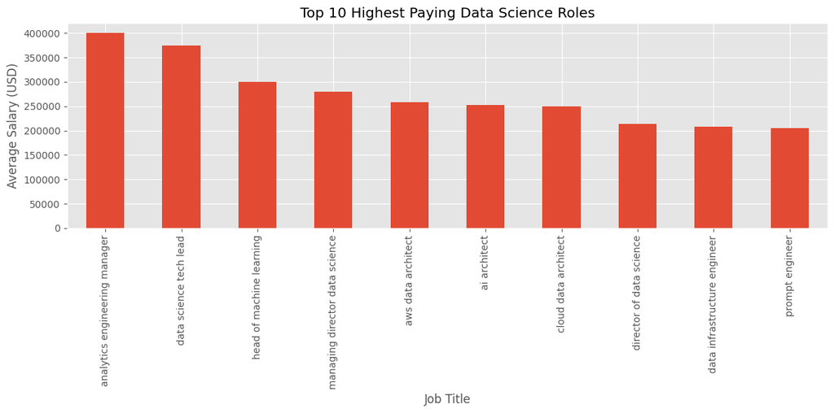

```python
top_salary = (
    salary_clean
    .groupby('job_title')['salary_in_usd']
    .mean()
    .sort_values(ascending=False)
    .head(10)
)

plt.figure(figsize=(12,6))

top_salary.plot(kind='bar')

plt.title("Top 10 Highest Paying Data Science Roles")
plt.xlabel("Job Title")
plt.ylabel("Average Salary (USD)")

plt.tight_layout()

plt.savefig("data/output/high_level_visualization.png")

plt.show()
```

## Detailed Visualization: Salary by Experience Level

This visualization focuses on the relationship between experience level and salary.

The chart highlights how compensation changes as professionals gain experience and advance in their careers.

This visualization provides a detailed view of one of the most important factors affecting salary.

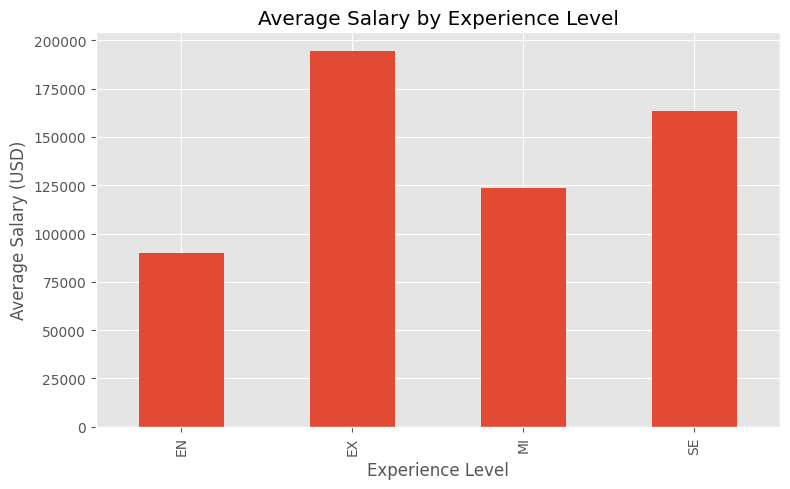

```python
experience_salary = (
    salary_clean
    .groupby('experience_level')['salary_in_usd']
    .mean()
)

plt.figure(figsize=(8,5))

experience_salary.plot(kind='bar')

plt.title("Average Salary by Experience Level")

plt.xlabel("Experience Level")
plt.ylabel("Average Salary (USD)")

plt.tight_layout()

plt.savefig("data/output/detailed_visualization.png")

plt.show()
```

## Salary Distribution Analysis

Understanding salary distribution provides insight into how salaries are spread across the data science workforce.

This histogram identifies common salary ranges and highlights the overall compensation structure within the industry.

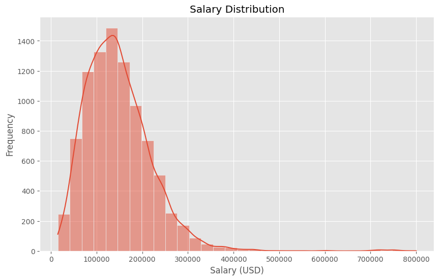

```python
plt.figure(figsize=(10,6))

sns.histplot(
    salary_clean['salary_in_usd'],
    bins=30,
    kde=True
)

plt.title("Salary Distribution")

plt.xlabel("Salary (USD)")
plt.ylabel("Frequency")

plt.savefig("data/output/salary_distribution.png")

plt.show()
```

## Remote Work Distribution

Remote work has become an important aspect of modern employment.

This visualization shows the distribution of remote, hybrid, and on-site work arrangements within the data science industry.

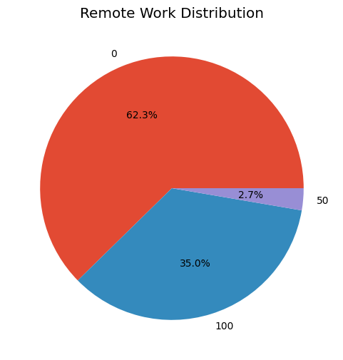

```python
remote_data = salary_clean['remote_ratio'].value_counts()

plt.figure(figsize=(6,6))

plt.pie(
    remote_data,
    labels=remote_data.index,
    autopct='%1.1f%%'
)

plt.title("Remote Work Distribution")

plt.savefig("data/output/remote_work_distribution.png")

plt.show()
```

## Company Size and Salary Analysis

Company size may influence employee compensation.

This chart compares average salaries across small, medium, and large organizations to identify compensation differences associated with company size.

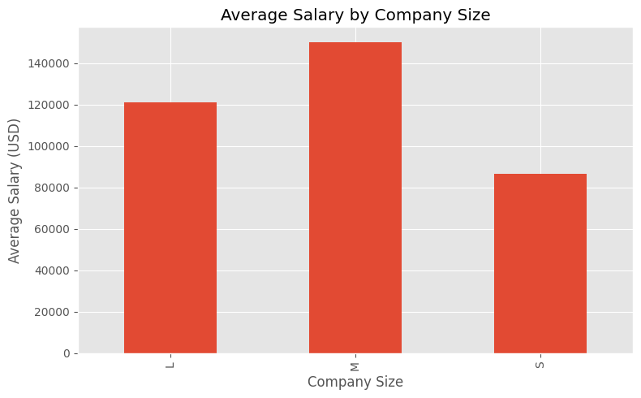

```python
company_salary = (
    salary_clean
    .groupby('company_size')['salary_in_usd']
    .mean()
)

plt.figure(figsize=(8,5))

company_salary.plot(kind='bar')

plt.title("Average Salary by Company Size")

plt.xlabel("Company Size")
plt.ylabel("Average Salary (USD)")

plt.tight_layout()

plt.savefig("data/output/company_size_salary.png")

plt.show()
```

## Job Demand versus Salary Analysis

This visualization integrates multiple data attributes into a single chart.

The analysis combines:

- Average salary
- Job demand
- Job category

This visualization helps identify roles that offer both strong compensation and high market demand.

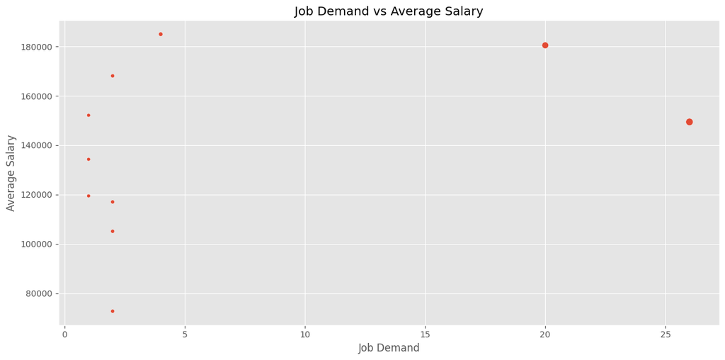

```python
top_merge = (
    merged_df
    .sort_values(
        by='avg_salary',
        ascending=False
    )
    .head(15)
)

plt.figure(figsize=(12,6))

sns.scatterplot(
    data=top_merge,
    x='job_count',
    y='avg_salary',
    size='job_count',
    legend=False
)

plt.title("Job Demand vs Average Salary")

plt.xlabel("Job Demand")
plt.ylabel("Average Salary")

plt.tight_layout()

plt.savefig("data/output/job_demand_vs_salary.png")

plt.show()
```

# Insights and Findings

## Conclusion

This analysis successfully combined multiple datasets to examine salary trends, job demand, experience requirements, and workplace characteristics within the data science industry. The findings provide valuable information for employers, recruiters, and job seekers making data-driven decisions.